# Bayesian Association of MTS with Seizure Freedom

Adam Dickey

2025-07-21

A published meta-analysis of 258 patients found that presence of mesial temporal sclerosis (MTS) predicts better chance of seizure freedom after minimally invasive epilepsy surgery (Kohlhase et al. 2021). Here, “seizure freedom” means freedom from disabling seizures, or Engel I outcome. They reported 63% seizure free with MTS and 42% without. The gives an odds ratio of **2.35**.

### Traditional meta-analysis

I can re-analyze that data to predict the odds ratio directly using the R package “**meta**” (as opposed to calculating the percent seizure free in each group).

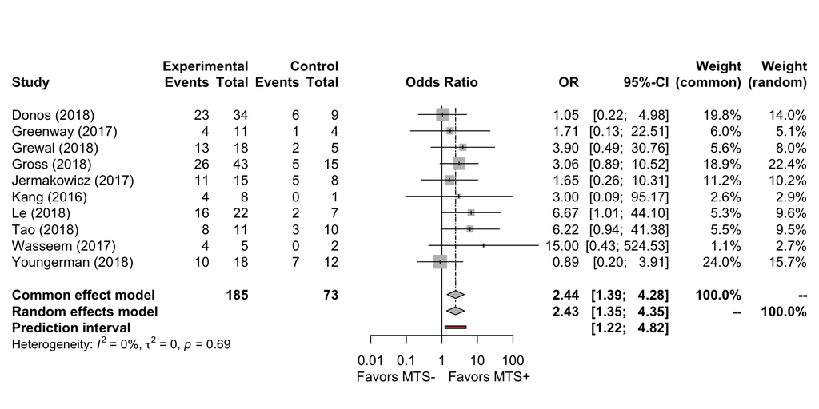

```r
outcome="OR"
df <- read_excel(fname,sheet="Kohlhase")
#NORMAL meta-analysis
m.publ=metabin(Apos, nA, Bpos, nB, data=df, studlab=paste0(Author, " (", Year, ")"),
               method.tau = "PM", sm=outcome)
orMeta <- exp(m.publ$TE.random)
forest(m.publ,  prediction=TRUE, label.right = paste0("Favors ",df$Aclass[1]),
       label.left = paste0("Favors ",df$Bclass[1]))
```

The random effects model gives a similar estimated odds ratio of **2.43**, and the 95% confidence interval excludes an odds ratio of one (no association).

### Bayesian meta-analysis

A Bayesian meta-analysis can be performed with the R package “**bayesmeta**” (Röver and Friede 2023). The main difference is we now include a prior distribution for how large we expect the odds ratios to be for predicting seizure freedom after epilepsy surgery. I previously argued for using a normal prior distribution for the log-odds ratio with mean 0 and standard deviation of 0.7 (Dickey et al. 2024). This implies belief that 95% of odds ratios are between 1/4 and 4.

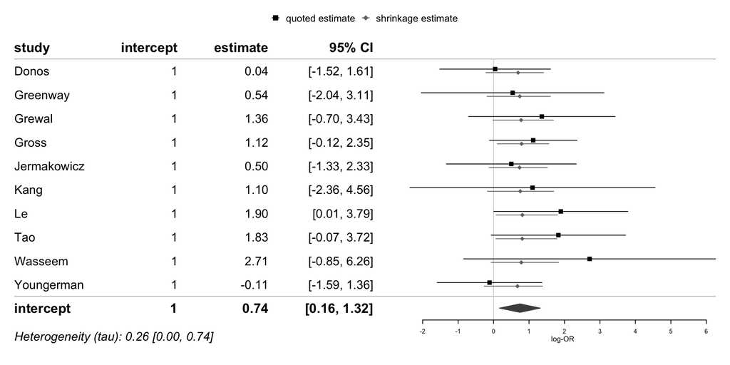

```r
#Calculate OR for the studies
es <- escalc(measure="OR",ai=Apos,n1i=nA,ci=Bpos,n2i=nB,slab=Author,data=df)

#Bayesian  meta-analysis
bmr1 <- bmr(es,beta.prior.mean=0,beta.prior.sd=0.7,
            tau.prior =function(t){dhalfnormal(t,s=0.5)})
forestplot(bmr1,xlab='log-OR')
```

Based on the data included in the published meta-analysis, the Bayesian estimate of the log-odds ratio is 0.74, which corresponds to an odds ratio of **2.10**. That value is less than traditional meta-analysis, because the prior distribution shrank the estimate towards the null value (odds ratio of one).

The 95% credible interval for the log-odds ratio excludes zero, and we are **99.4%** sure that the odds ratio is bigger than one. Based on the Bayesian meta-analysis, we are quite sure that MTS predicts seizure freedom after minimally invasive epilepsy surgery.

### Adding the LAANTERN study

The recently published LAANTERN study reported that 40/60 (66.7%) of patients with MTS were seizure free after minimally invasive epilepsy surgery, compared to 11/25 (44%) of patients without MTS (Landazuri et al. 2025). Those numbers are remarkably similar to the results of the meta-analysis (63% seizure with MTS vs. 42% without). In fact, the observed odds ratio of **2.55** is bigger than was observed in either the traditional or Bayesian meta-analysis. If anything, this data should increase our belief in the predictive value of MTS.

However, using traditional **frequentist** statistics, the observed difference of 40/60 versus 11/25 seizure free is not significant at p < 0.05 (**p = 0.088**, Fisher exact test). We have been taught to “fail to reject the null” and report no association. Hence, the authors concluded that “MTS was not associated with outcome.”

In contrast, a **Bayesian** approach uses the observed data to update our prior belief, which can derive from the published meta-analysis. We can do this by adding the LAANTERN study to our Bayesian meta-analysis.

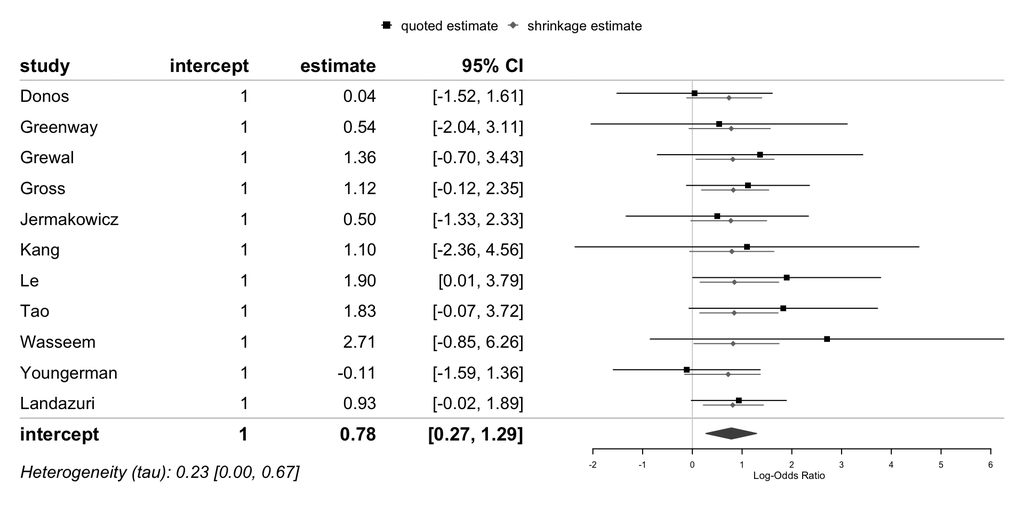

```r
df2 <- read_excel(fname,sheet="Landazuri") #add new study

#Calculate OR for the studies
es2 <- escalc(measure="OR",ai=Apos,n1i=nA,ci=Bpos,n2i=nB,slab=Author,data=df2)

#Bayesian  meta-analysis
bmr2 <- bmr(es2,beta.prior.mean=0,beta.prior.sd=0.7,
            tau.prior =function(t){dhalfnormal(t,s=0.5)})
forestplot(bmr2,xlab='Log-Odds Ratio')
```

When the new data is added, the updated Bayesian estimate of the odds ratio is **2.19**, and we are **99.9%** sure that the odds ratio is bigger than one. Thus the newly published LAANTERN study increased the estimate of the odds ratio for MTS predicting seizure freedom, and increased our belief in a positive association.

### Conclusion

There is stark difference between the frequentist interpretation of no association between MTS and seizure outcome, and the Bayesian interpretation of more than 99% certainty there is a positive association. It has been argued that traditional frequentist null hypothesis testing does not work well when studying small effects with noisy data, and that Bayesian inference represents a way forward (Gelman 2018). The expected effect size of most pre-surgical predictors is small (odds ratio ~ 2), and measurement of seizure outcome is noisy. Therefore, we argue that Bayesian inference provides a better framework for studying predictors of seizure freedom after epilepsy.

### References

Dickey, Adam S., Vineet Reddy, Nigel P. Pedersen, and Robert T. Krafty. 2024. “Bayesian Estimation Improves Prediction of Outcomes After Epilepsy Surgery.” https://doi.org/10.1101/2024.06.21.24309313.

Gelman, Andrew. 2018. “The Failure of Null Hypothesis Significance Testing When Studying Incremental Changes, and What to Do About It.” *Personality and Social Psychology Bulletin* 44 (1): 16–23. https://doi.org/10.1177/0146167217729162.

Kohlhase, Konstantin, Johann Philipp Zöllner, Nitin Tandon, Adam Strzelczyk, and Felix Rosenow. 2021. “Comparison of Minimally Invasive and Traditional Surgical Approaches for Refractory Mesial Temporal Lobe Epilepsy: A Systematic Review and Meta‐analysis of Outcomes.” *Epilepsia* 62 (4): 831–45. https://doi.org/10.1111/epi.16846.

Landazuri, Patrick, Jennifer J. Cheng, Eric Leuthardt, Albert H. Kim, Derek G. Southwell, Peter E. Fecci, Joseph Neimat, et al. 2025. “Interstitial Thermal Therapy in Mesial Temporal Lobe Epilepsy.” *JAMA Neurology*, July. https://doi.org/10.1001/jamaneurol.2025.1897.

Röver, Christian, and Tim Friede. 2023. “Using the Bayesmeta R Package for Bayesian Random-Effects Meta-Regression.” *Computer Methods and Programs in Biomedicine* 229 (February): 107303. https://doi.org/10.1016/j.cmpb.2022.107303.